# Data cleaning: Unemployment

Gabriel Urbina

11 diciembre, 2021

# What do I have in the data set “unemployment”?

```r
# load data set: unemployment ----

unemployment <- fread(paste0(data, "unemployment.csv"))

# get variable names:

names(unemployment)
```

[1] “Year” “Month” “District Code”  
[4] “District Name” “Neighborhood Code” “Neighborhood Name” [7] “Gender” “Demand_occupation” “Number”

```r
# modify variables names: ----

colnames(unemployment) <-
  gsub(" ",
       "_",
       colnames(unemployment))

# get a summary of the data set: ----

summary(unemployment)
```

```
  Year         Month           District_Code  District_Name
```

Min. :2013 Length:14208 Min. : 1.0 Length:14208  
1st Qu.:2015 Class :character 1st Qu.: 4.0 Class :character  
Median :2016 Mode :character Median : 7.0 Mode :character  
Mean :2015 Mean : 7.5  
3rd Qu.:2016 3rd Qu.: 8.0  
Max. :2017 Max. :99.0  
Neighborhood_Code Neighborhood_Name Gender Demand_occupation Min. : 1.00 Length:14208 Length:14208 Length:14208  
1st Qu.:19.00 Class :character Class :character Class :character  
Median :37.50 Mode :character Mode :character Mode :character  
Mean :37.84  
3rd Qu.:56.00  
Max. :99.00  
Number  
Min. : 0.0  
1st Qu.: 121.0  
Median : 296.0  
Mean : 446.7  
3rd Qu.: 685.0  
Max. :3094.0

```r
# keep only data for 2017: ----

unemployment.2017 <-
  unemployment[Year == "2017"]

# summary: unemployment 2017 ----

summary(unemployment.2017)
```

```
  Year         Month           District_Code  District_Name
```

Min. :2017 Length:3552 Min. : 1.0 Length:3552  
1st Qu.:2017 Class :character 1st Qu.: 4.0 Class :character  
Median :2017 Mode :character Median : 7.0 Mode :character  
Mean :2017 Mean : 7.5  
3rd Qu.:2017 3rd Qu.: 8.0  
Max. :2017 Max. :99.0  
Neighborhood_Code Neighborhood_Name Gender Demand_occupation Min. : 1.00 Length:3552 Length:3552 Length:3552  
1st Qu.:19.00 Class :character Class :character Class :character  
Median :37.50 Mode :character Mode :character Mode :character  
Mean :37.84  
3rd Qu.:56.00  
Max. :99.00  
Number  
Min. : 0.0  
1st Qu.: 92.0  
Median : 205.5  
Mean : 320.4  
3rd Qu.: 461.2  
Max. :2109.0

```r
# set NA values: characters ----

unemployment.2017 <- unemployment.2017[,
                  lapply(.SD, function(x) ifelse(
                  x == "No consta", NA, x
                  )), .SDcols = names(unemployment.2017)]

# set NA values: integers ----

unemployment.2017 <- unemployment.2017[,
                    lapply(
                          .SD,
                          function(x) ifelse(
                            x == 99,
                            NA,
                            x
                          )),
                    .SDcols = names(
                      unemployment.2017
                    )]

# create the total unemployment column: ----
# at neighborhood frequency

unemployment.2017 <-
  unemployment.2017[,
               unemployment :=
                 sum(Number,
                     na.rm = TRUE),
               by = c(
                 "District_Name",
                 "Neighborhood_Name"
               )
]

# generate unemployment by sex: ----

unemployment.2017 <-
  unemployment.2017[,
   c("female_unemployment",
     "male_unemployment"):=
     .(max(ifelse(
       Gender == "Female",
       sum(Number,
         na.rm = TRUE),
       0)),
       max(ifelse(
         Gender == "Male",
         sum(Number,
           na.rm = TRUE),
         0))),
   by = c(
     "District_Name",
     "Neighborhood_Name",
     "Gender"
   )
  ]

# replace zeros by the maximum value per neighborhood: ----
# values per sex are side by side

unemployment.2017 <-
  unemployment.2017[,
   c("female_unemployment",
     "male_unemployment"):=
     .(max(female_unemployment),
       max(male_unemployment)),
   by =c(
     "District_Name",
     "Neighborhood_Name"
   )]

# create an index variable: Month-District_Name,
# Neighborhood_Name ----

unemployment.2017 <-
  unemployment.2017[, index := 1:.N,
                   by= c(
# at neighboorhood level
      "Neighborhood_Code")
]

# keep one observation per Month-District-Neighborhood: ----

unemployment.2017 <-
  unemployment.2017[index == 1]

# keep variables of interest: ----

unemployment.2017 <- unemployment.2017[,
                  .(District_Code,
                    District_Name,
                    Neighborhood_Code,
                    Neighborhood_Name,
                    unemployment,
                    female_unemployment,
                    male_unemployment)]

# how many duplicated cases exist ----

table(duplicated(unemployment.2017))
```

FALSE 74

```r
# check duplicated neighborhood names per district ----
table(
  unemployment.2017$District_Name,
  unemployment.2017$Neighborhood_Name)
```

```
                  Baró de Viver Can Baró Can Peguera Canyelles
```

Ciutat Vella 0 0 0 0 Eixample 0 0 0 0 Gràcia 0 0 0 0 Horta-Guinardó 0 1 0 0 Les Corts 0 0 0 0 Nou Barris 0 0 1 1 Sant Andreu 1 0 0 0 Sant Martí 0 0 0 0 Sants-Montjuïc 0 0 0 0 Sarrià-Sant Gervasi 0 0 0 0

```
                  Ciutat Meridiana
```

Ciutat Vella 0 Eixample 0 Gràcia 0 Horta-Guinardó 0 Les Corts 0 Nou Barris 1 Sant Andreu 0 Sant Martí 0 Sants-Montjuïc 0 Sarrià-Sant Gervasi 0

```
                  Diagonal Mar i el Front Marítim del Poblenou
```

Ciutat Vella 0 Eixample 0 Gràcia 0 Horta-Guinardó 0 Les Corts 0 Nou Barris 0 Sant Andreu 0 Sant Martí 1 Sants-Montjuïc 0 Sarrià-Sant Gervasi 0

```
                  el Baix Guinardó el Barri Gòtic el Besòs i el Maresme
```

Ciutat Vella 0 1 0 Eixample 0 0 0 Gràcia 0 0 0 Horta-Guinardó 1 0 0 Les Corts 0 0 0 Nou Barris 0 0 0 Sant Andreu 0 0 0 Sant Martí 0 0 1 Sants-Montjuïc 0 0 0 Sarrià-Sant Gervasi 0 0 0

```
                  el Bon Pastor el Camp d'en Grassot i Gràcia Nova
```

Ciutat Vella 0 0 Eixample 0 0 Gràcia 0 1 Horta-Guinardó 0 0 Les Corts 0 0 Nou Barris 0 0 Sant Andreu 1 0 Sant Martí 0 0 Sants-Montjuïc 0 0 Sarrià-Sant Gervasi 0 0

```
                  el Camp de l'Arpa del Clot el Carmel el Clot el Coll
```

Ciutat Vella 0 0 0 0 Eixample 0 0 0 0 Gràcia 0 0 0 1 Horta-Guinardó 0 1 0 0 Les Corts 0 0 0 0 Nou Barris 0 0 0 0 Sant Andreu 0 0 0 0 Sant Martí 1 0 1 0 Sants-Montjuïc 0 0 0 0 Sarrià-Sant Gervasi 0 0 0 0

```
                  el Congrés i els Indians el Fort Pienc el Guinardó
```

Ciutat Vella 0 0 0 Eixample 0 1 0 Gràcia 0 0 0 Horta-Guinardó 0 0 1 Les Corts 0 0 0 Nou Barris 0 0 0 Sant Andreu 1 0 0 Sant Martí 0 0 0 Sants-Montjuïc 0 0 0 Sarrià-Sant Gervasi 0 0 0

```
                  el Parc i la Llacuna del Poblenou el Poble Sec
```

Ciutat Vella 0 0 Eixample 0 0 Gràcia 0 0 Horta-Guinardó 0 0 Les Corts 0 0 Nou Barris 0 0 Sant Andreu 0 0 Sant Martí 1 0 Sants-Montjuïc 0 1 Sarrià-Sant Gervasi 0 0

```
                  el Poblenou el Putxet i el Farró el Raval
```

Ciutat Vella 0 0 1 Eixample 0 0 0 Gràcia 0 0 0 Horta-Guinardó 0 0 0 Les Corts 0 0 0 Nou Barris 0 0 0 Sant Andreu 0 0 0 Sant Martí 1 0 0 Sants-Montjuïc 0 0 0 Sarrià-Sant Gervasi 0 1 0

```
                  el Turó de la Peira Horta Hostafrancs
```

Ciutat Vella 0 0 0 Eixample 0 0 0 Gràcia 0 0 0 Horta-Guinardó 0 1 0 Les Corts 0 0 0 Nou Barris 1 0 0 Sant Andreu 0 0 0 Sant Martí 0 0 0 Sants-Montjuïc 0 0 1 Sarrià-Sant Gervasi 0 0 0

```
                  l'Antiga Esquerra de l'Eixample la Barceloneta la Bordeta
```

Ciutat Vella 0 1 0 Eixample 1 0 0 Gràcia 0 0 0 Horta-Guinardó 0 0 0 Les Corts 0 0 0 Nou Barris 0 0 0 Sant Andreu 0 0 0 Sant Martí 0 0 0 Sants-Montjuïc 0 0 1 Sarrià-Sant Gervasi 0 0 0

```
                  la Clota la Dreta de l'Eixample la Font d'en Fargues
```

Ciutat Vella 0 0 0 Eixample 0 1 0 Gràcia 0 0 0 Horta-Guinardó 1 0 1 Les Corts 0 0 0 Nou Barris 0 0 0 Sant Andreu 0 0 0 Sant Martí 0 0 0 Sants-Montjuïc 0 0 0 Sarrià-Sant Gervasi 0 0 0

```
                  la Font de la Guatlla la Guineueta la Marina de Port
```

Ciutat Vella 0 0 0 Eixample 0 0 0 Gràcia 0 0 0 Horta-Guinardó 0 0 0 Les Corts 0 0 0 Nou Barris 0 1 0 Sant Andreu 0 0 0 Sant Martí 0 0 0 Sants-Montjuïc 1 0 1 Sarrià-Sant Gervasi 0 0 0

```
                  la Marina del Prat Vermell la Maternitat i Sant Ramon
```

Ciutat Vella 0 0 Eixample 0 0 Gràcia 0 0 Horta-Guinardó 0 0 Les Corts 0 1 Nou Barris 0 0 Sant Andreu 0 0 Sant Martí 0 0 Sants-Montjuïc 1 0 Sarrià-Sant Gervasi 0 0

```
                  la Nova Esquerra de l'Eixample la Prosperitat
```

Ciutat Vella 0 0 Eixample 1 0 Gràcia 0 0 Horta-Guinardó 0 0 Les Corts 0 0 Nou Barris 0 1 Sant Andreu 0 0 Sant Martí 0 0 Sants-Montjuïc 0 0 Sarrià-Sant Gervasi 0 0

```
                  la Sagrada Família la Sagrera la Salut la Teixonera
```

Ciutat Vella 0 0 0 0 Eixample 1 0 0 0 Gràcia 0 0 1 0 Horta-Guinardó 0 0 0 1 Les Corts 0 0 0 0 Nou Barris 0 0 0 0 Sant Andreu 0 1 0 0 Sant Martí 0 0 0 0 Sants-Montjuïc 0 0 0 0 Sarrià-Sant Gervasi 0 0 0 0

```
                  la Trinitat Nova la Trinitat Vella la Vall d'Hebron
```

Ciutat Vella 0 0 0 Eixample 0 0 0 Gràcia 0 0 0 Horta-Guinardó 0 0 1 Les Corts 0 0 0 Nou Barris 1 0 0 Sant Andreu 0 1 0 Sant Martí 0 0 0 Sants-Montjuïc 0 0 0 Sarrià-Sant Gervasi 0 0 0

```
                  la Verneda i la Pau la Vila de Gràcia
```

Ciutat Vella 0 0 Eixample 0 0 Gràcia 0 1 Horta-Guinardó 0 0 Les Corts 0 0 Nou Barris 0 0 Sant Andreu 0 0 Sant Martí 1 0 Sants-Montjuïc 0 0 Sarrià-Sant Gervasi 0 0

```
                  la Vila Olímpica del Poblenou les Corts les Roquetes
```

Ciutat Vella 0 0 0 Eixample 0 0 0 Gràcia 0 0 0 Horta-Guinardó 0 0 0 Les Corts 0 1 0 Nou Barris 0 0 1 Sant Andreu 0 0 0 Sant Martí 1 0 0 Sants-Montjuïc 0 0 0 Sarrià-Sant Gervasi 0 0 0

```
                  les Tres Torres Montbau Navas Pedralbes Porta
```

Ciutat Vella 0 0 0 0 0 Eixample 0 0 0 0 0 Gràcia 0 0 0 0 0 Horta-Guinardó 0 1 0 0 0 Les Corts 0 0 0 1 0 Nou Barris 0 0 0 0 1 Sant Andreu 0 0 1 0 0 Sant Martí 0 0 0 0 0 Sants-Montjuïc 0 0 0 0 0 Sarrià-Sant Gervasi 1 0 0 0 0

```
                  Provençals del Poblenou Sant Andreu Sant Antoni
```

Ciutat Vella 0 0 0 Eixample 0 0 1 Gràcia 0 0 0 Horta-Guinardó 0 0 0 Les Corts 0 0 0 Nou Barris 0 0 0 Sant Andreu 0 1 0 Sant Martí 1 0 0 Sants-Montjuïc 0 0 0 Sarrià-Sant Gervasi 0 0 0

```
                  Sant Genís dels Agudells Sant Gervasi - Galvany
```

Ciutat Vella 0 0 Eixample 0 0 Gràcia 0 0 Horta-Guinardó 1 0 Les Corts 0 0 Nou Barris 0 0 Sant Andreu 0 0 Sant Martí 0 0 Sants-Montjuïc 0 0 Sarrià-Sant Gervasi 0 1

```
                  Sant Gervasi - la Bonanova Sant Martí de Provençals
```

Ciutat Vella 0 0 Eixample 0 0 Gràcia 0 0 Horta-Guinardó 0 0 Les Corts 0 0 Nou Barris 0 0 Sant Andreu 0 0 Sant Martí 0 1 Sants-Montjuïc 0 0 Sarrià-Sant Gervasi 1 0

```
                  Sant Pere, Santa Caterina i la Ribera Sants Sants - Badal
```

Ciutat Vella 1 0 0 Eixample 0 0 0 Gràcia 0 0 0 Horta-Guinardó 0 0 0 Les Corts 0 0 0 Nou Barris 0 0 0 Sant Andreu 0 0 0 Sant Martí 0 0 0 Sants-Montjuïc 0 1 1 Sarrià-Sant Gervasi 0 0 0

```
                  Sarrià Torre Baró Vallbona Vallcarca i els Penitents
```

Ciutat Vella 0 0 0 0 Eixample 0 0 0 0 Gràcia 0 0 0 1 Horta-Guinardó 0 0 0 0 Les Corts 0 0 0 0 Nou Barris 0 1 1 0 Sant Andreu 0 0 0 0 Sant Martí 0 0 0 0 Sants-Montjuïc 0 0 0 0 Sarrià-Sant Gervasi 1 0 0 0

```
                  Vallvidrera, el Tibidabo i les Planes Verdun
```

Ciutat Vella 0 0 Eixample 0 0 Gràcia 0 0 Horta-Guinardó 0 0 Les Corts 0 0 Nou Barris 0 1 Sant Andreu 0 0 Sant Martí 0 0 Sants-Montjuïc 0 0 Sarrià-Sant Gervasi 1 0

```
                  Vilapicina i la Torre Llobeta
```

Ciutat Vella 0 Eixample 0 Gràcia 0 Horta-Guinardó 0 Les Corts 0 Nou Barris 1 Sant Andreu 0 Sant Martí 0 Sants-Montjuïc 0 Sarrià-Sant Gervasi 0

```r
# No duplicated cases.
```

```r
# checking how many NA still remains ----

table(complete.cases(unemployment.2017))
```

FALSE TRUE 1 73

```r
# Drop NAs ----

unemployment.2017 <- na.omit(unemployment.2017)
```

# Visualization

In general, there are neighborhood with persistent unemployment.

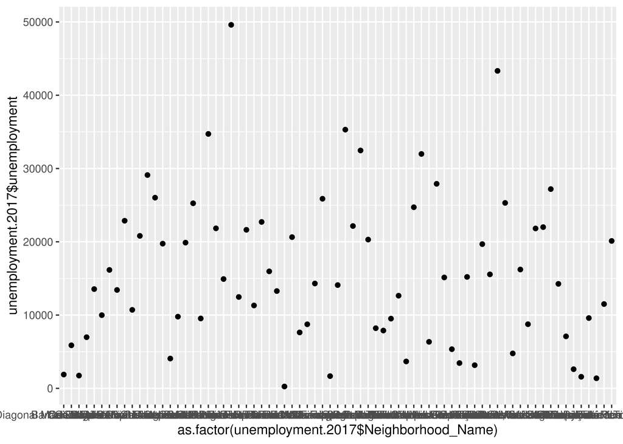

```r
unemployment.2017 %>%
  ggplot(aes(as.factor(unemployment.2017$Neighborhood_Name),
     unemployment.2017$unemployment)
     ) +
  geom_point()
```